# Trade&Ahead Project

### Context

The stock market has consistently proven to be a good place to invest in and save for the future. There are a lot of compelling reasons to invest in stocks. It can help in fighting inflation, create wealth, and also provides some tax benefits. Good steady returns on investments over a long period of time can also grow a lot more than seems possible. Also, thanks to the power of compound interest, the earlier one starts investing, the larger the corpus one can have for retirement. Overall, investing in stocks can help meet life's financial aspirations.

It is important to maintain a diversified portfolio when investing in stocks in order to maximize earnings under any market condition. Having a diversified portfolio tends to yield higher returns and face lower risk by tempering potential losses when the market is down. It is often easy to get lost in a sea of financial metrics to analyze while determining the worth of a stock, and doing the same for a multitude of stocks to identify the right picks for an individual can be a tedious task. By doing a cluster analysis, one can identify stocks that exhibit similar characteristics and ones that exhibit minimum correlation. This will help investors better analyze stocks across different market segments and help protect against risks that could make the portfolio vulnerable to losses.

### Objective

Trade&Ahead is a financial consultancy firm who provide their customers with personalized investment strategies. They have hired me as a Data Scientist and provided me with data comprising stock price and some financial indicators for a few companies listed under the New York Stock Exchange. They have assigned me the tasks of analyzing the data, grouping the stocks based on the attributes provided, and sharing insights about the characteristics of each group.

### Data Description

The data provided is of stock prices and some financial indicators like ROE, earnings per share, P/E ratio, etc.

### Data Dictionary

- Ticker Symbol: An abbreviation used to uniquely identify publicly traded shares of a particular stock on a particular stock market
- Company: Name of the company
- GICS Sector: The specific economic sector assigned to a company by the Global Industry Classification Standard (GICS) that best defines its business operations
- GICS Sub Industry: The specific sub-industry group assigned to a company by the Global Industry Classification Standard (GICS) that best defines its business operations
- Current Price: Current stock price in dollars
- Price Change: Percentage change in the stock price in 13 weeks
- Volatility: Standard deviation of the stock price over the past 13 weeks
- ROE: A measure of financial performance calculated by dividing net income by shareholders' equity (shareholders' equity is equal to a company's assets minus its debt)
- Cash Ratio: The ratio of a company's total reserves of cash and cash equivalents to its total current liabilities
- Net Cash Flow: The difference between a company's cash inflows and outflows (in dollars)
- Net Income: Revenues minus expenses, interest, and taxes (in dollars)
- Earnings Per Share: Company's net profit divided by the number of common shares it has outstanding (in dollars)
- Estimated Shares Outstanding: Company's stock currently held by all its shareholders
- P/E Ratio: Ratio of the company's current stock price to the earnings per share
- P/B Ratio: Ratio of the company's stock price per share by its book value per share (book value of a company is the net difference between that company's total assets and total liabilities)

## Importing necessary libraries and data

```python
# this will help in making the Python code more structured automatically (good coding practice)
%load_ext nb_black

# Libraries to help with reading and manipulating data
import numpy as np
import pandas as pd

# Libraries to help with data visualization
import matplotlib.pyplot as plt
import seaborn as sns

# Removes the limit for the number of displayed columns
pd.set_option("display.max_columns", None)
# Sets the limit for the number of displayed rows
pd.set_option("display.max_rows", 200)

# to scale the data using z-score
from sklearn.preprocessing import StandardScaler

# to compute distances
from scipy.spatial.distance import pdist
from scipy.spatial.distance import cdist

# to perform hierarchical clustering, compute cophenetic correlation, and create dendrograms
from sklearn.cluster import AgglomerativeClustering
from scipy.cluster.hierarchy import dendrogram, linkage, cophenet

# to perform PCA
from sklearn.decomposition import PCA

# KMeans Clustering
from sklearn.cluster import KMeans
from sklearn.metrics import silhouette_score
from yellowbrick.cluster import KElbowVisualizer, SilhouetteVisualizer
```

### Read the dataset

```python
# loading the dataset
stock = pd.read_csv("stock_data.csv")
```

```python
# copying data to another varaible to avoid any changes to original data
data = stock.copy()
```

## Data Overview

### View the first and last 5 rows of the dataset.

```python
data.head()
```

|  | Ticker Symbol | Security | GICS Sector | GICS Sub Industry | Current Price | Price Change | Volatility | ROE | Cash Ratio | Net Cash Flow | Net Income | Earnings Per Share | Estimated Shares Outstanding | P/E Ratio | P/B Ratio |
| --- | --- | --- | --- | --- | --- | --- | --- | --- | --- | --- | --- | --- | --- | --- | --- |
| 0 | AAL | American Airlines Group | Industrials | Airlines | 42.349998 | 9.999995 | 1.687151 | 135 | 51 | -604000000 | 7610000000 | 11.39 | 6.681299e+08 | 3.718174 | -8.784219 |
| 1 | ABBV | AbbVie | Health Care | Pharmaceuticals | 59.240002 | 8.339433 | 2.197887 | 130 | 77 | 51000000 | 5144000000 | 3.15 | 1.633016e+09 | 18.806350 | -8.750068 |
| 2 | ABT | Abbott Laboratories | Health Care | Health Care Equipment | 44.910000 | 11.301121 | 1.273646 | 21 | 67 | 938000000 | 4423000000 | 2.94 | 1.504422e+09 | 15.275510 | -0.394171 |
| 3 | ADBE | Adobe Systems Inc | Information Technology | Application Software | 93.940002 | 13.977195 | 1.357679 | 9 | 180 | -240840000 | 629551000 | 1.26 | 4.996437e+08 | 74.555557 | 4.199651 |
| 4 | ADI | Analog Devices, Inc. | Information Technology | Semiconductors | 55.320000 | -1.827858 | 1.701169 | 14 | 272 | 315120000 | 696878000 | 0.31 | 2.247994e+09 | 178.451613 | 1.059810 |

```python
data.tail()
```

|  | Ticker Symbol | Security | GICS Sector | GICS Sub Industry | Current Price | Price Change | Volatility | ROE | Cash Ratio | Net Cash Flow | Net Income | Earnings Per Share | Estimated Shares Outstanding | P/E Ratio | P/B Ratio |
| --- | --- | --- | --- | --- | --- | --- | --- | --- | --- | --- | --- | --- | --- | --- | --- |
| 335 | YHOO | Yahoo Inc. | Information Technology | Internet Software & Services | 33.259998 | 14.887727 | 1.845149 | 15 | 459 | -1032187000 | -4359082000 | -4.64 | 939457327.6 | 28.976191 | 6.261775 |
| 336 | YUM | Yum! Brands Inc | Consumer Discretionary | Restaurants | 52.516175 | -8.698917 | 1.478877 | 142 | 27 | 159000000 | 1293000000 | 2.97 | 435353535.4 | 17.682214 | -3.838260 |
| 337 | ZBH | Zimmer Biomet Holdings | Health Care | Health Care Equipment | 102.589996 | 9.347683 | 1.404206 | 1 | 100 | 376000000 | 147000000 | 0.78 | 188461538.5 | 131.525636 | -23.884449 |
| 338 | ZION | Zions Bancorp | Financials | Regional Banks | 27.299999 | -1.158588 | 1.468176 | 4 | 99 | -43623000 | 309471000 | 1.20 | 257892500.0 | 22.749999 | -0.063096 |
| 339 | ZTS | Zoetis | Health Care | Pharmaceuticals | 47.919998 | 16.678836 | 1.610285 | 32 | 65 | 272000000 | 339000000 | 0.68 | 498529411.8 | 70.470585 | 1.723068 |

### Understand the shape of the dataset.

```python
data.shape
```

```
(340, 15)
```

- There are 340 observations and 15 columns in the dataset

### Check the data types of the columns for the dataset.

```python
data.info()
```

```
<class 'pandas.core.frame.DataFrame'>
RangeIndex: 340 entries, 0 to 339
Data columns (total 15 columns):
 #   Column                        Non-Null Count  Dtype
---  ------                        --------------  -----
 0   Ticker Symbol                 340 non-null    object
 1   Security                      340 non-null    object
 2   GICS Sector                   340 non-null    object
 3   GICS Sub Industry             340 non-null    object
 4   Current Price                 340 non-null    float64
 5   Price Change                  340 non-null    float64
 6   Volatility                    340 non-null    float64
 7   ROE                           340 non-null    int64
 8   Cash Ratio                    340 non-null    int64
 9   Net Cash Flow                 340 non-null    int64
 10  Net Income                    340 non-null    int64
 11  Earnings Per Share            340 non-null    float64
 12  Estimated Shares Outstanding  340 non-null    float64
 13  P/E Ratio                     340 non-null    float64
 14  P/B Ratio                     340 non-null    float64
dtypes: float64(7), int64(4), object(4)
memory usage: 40.0+ KB
```

**Observations**

- Most of the data-types are numerical, either float or int.
- Only four columns Ticker Symbol, Security, GICS Sector and GICS Sub Industry are of type Object.
- There are no null values in the dataset.

## Data Preprocessing

### Let's check the duplicate data. And if any, we should remove it.

```python
data[data.duplicated()].count()
```

```
Ticker Symbol                   0
Security                        0
GICS Sector                     0
GICS Sub Industry               0
Current Price                   0
Price Change                    0
Volatility                      0
ROE                             0
Cash Ratio                      0
Net Cash Flow                   0
Net Income                      0
Earnings Per Share              0
Estimated Shares Outstanding    0
P/E Ratio                       0
P/B Ratio                       0
dtype: int64
```

- There are no duplicate values in the dataset.

### Check for missing values

```python
data.isnull().sum()
```

```
Ticker Symbol                   0
Security                        0
GICS Sector                     0
GICS Sub Industry               0
Current Price                   0
Price Change                    0
Volatility                      0
ROE                             0
Cash Ratio                      0
Net Cash Flow                   0
Net Income                      0
Earnings Per Share              0
Estimated Shares Outstanding    0
P/E Ratio                       0
P/B Ratio                       0
dtype: int64
```

- There are no missing values in the dataset.

### Fixing column names

```python
data.columns = [c.replace(" ", "_") for c in data.columns]
data.columns
```

```
Index(['Ticker_Symbol', 'Security', 'GICS_Sector', 'GICS_Sub_Industry',
       'Current_Price', 'Price_Change', 'Volatility', 'ROE', 'Cash_Ratio',
       'Net_Cash_Flow', 'Net_Income', 'Earnings_Per_Share',
       'Estimated_Shares_Outstanding', 'P/E_Ratio', 'P/B_Ratio'],
      dtype='object')
```

### Fixing the datatypes

```python
# converting "objects" to "category" reduces the data space required to store the dataframe
cols = data.select_dtypes(["object"])
cols.columns
```

```
Index(['Ticker_Symbol', 'Security', 'GICS_Sector', 'GICS_Sub_Industry'], dtype='object')
```

```python
for i in cols.columns:
    data[i] = data[i].astype("category")
```

```python
data.info()
```

```
<class 'pandas.core.frame.DataFrame'>
RangeIndex: 340 entries, 0 to 339
Data columns (total 15 columns):
 #   Column                        Non-Null Count  Dtype
---  ------                        --------------  -----
 0   Ticker_Symbol                 340 non-null    category
 1   Security                      340 non-null    category
 2   GICS_Sector                   340 non-null    category
 3   GICS_Sub_Industry             340 non-null    category
 4   Current_Price                 340 non-null    float64
 5   Price_Change                  340 non-null    float64
 6   Volatility                    340 non-null    float64
 7   ROE                           340 non-null    int64
 8   Cash_Ratio                    340 non-null    int64
 9   Net_Cash_Flow                 340 non-null    int64
 10  Net_Income                    340 non-null    int64
 11  Earnings_Per_Share            340 non-null    float64
 12  Estimated_Shares_Outstanding  340 non-null    float64
 13  P/E_Ratio                     340 non-null    float64
 14  P/B_Ratio                     340 non-null    float64
dtypes: category(4), float64(7), int64(4)
memory usage: 58.1 KB
```

### Summary of the dataset

```python
# Numerical variables
data.describe().T
```

|  | count | mean | std | min | 25% | 50% | 75% | max |
| --- | --- | --- | --- | --- | --- | --- | --- | --- |
| Current_Price | 340.0 | 8.086234e+01 | 9.805509e+01 | 4.500000e+00 | 3.855500e+01 | 5.970500e+01 | 9.288000e+01 | 1.274950e+03 |
| Price_Change | 340.0 | 4.078194e+00 | 1.200634e+01 | -4.712969e+01 | -9.394838e-01 | 4.819505e+00 | 1.069549e+01 | 5.505168e+01 |
| Volatility | 340.0 | 1.525976e+00 | 5.917984e-01 | 7.331632e-01 | 1.134878e+00 | 1.385593e+00 | 1.695549e+00 | 4.580042e+00 |
| ROE | 340.0 | 3.959706e+01 | 9.654754e+01 | 1.000000e+00 | 9.750000e+00 | 1.500000e+01 | 2.700000e+01 | 9.170000e+02 |
| Cash_Ratio | 340.0 | 7.002353e+01 | 9.042133e+01 | 0.000000e+00 | 1.800000e+01 | 4.700000e+01 | 9.900000e+01 | 9.580000e+02 |
| Net_Cash_Flow | 340.0 | 5.553762e+07 | 1.946365e+09 | -1.120800e+10 | -1.939065e+08 | 2.098000e+06 | 1.698108e+08 | 2.076400e+10 |
| Net_Income | 340.0 | 1.494385e+09 | 3.940150e+09 | -2.352800e+10 | 3.523012e+08 | 7.073360e+08 | 1.899000e+09 | 2.444200e+10 |
| Earnings_Per_Share | 340.0 | 2.776662e+00 | 6.587779e+00 | -6.120000e+01 | 1.557500e+00 | 2.895000e+00 | 4.620000e+00 | 5.009000e+01 |
| Estimated_Shares_Outstanding | 340.0 | 5.770283e+08 | 8.458496e+08 | 2.767216e+07 | 1.588482e+08 | 3.096751e+08 | 5.731175e+08 | 6.159292e+09 |
| P/E_Ratio | 340.0 | 3.261256e+01 | 4.434873e+01 | 2.935451e+00 | 1.504465e+01 | 2.081988e+01 | 3.176476e+01 | 5.280391e+02 |
| P/B_Ratio | 340.0 | -1.718249e+00 | 1.396691e+01 | -7.611908e+01 | -4.352056e+00 | -1.067170e+00 | 3.917066e+00 | 1.290646e+02 |

```python
# Categorical Variables
data.describe(include=["category"]).T
```

|  | count | unique | top | freq |
| --- | --- | --- | --- | --- |
| Ticker_Symbol | 340 | 340 | AAL | 1 |
| Security | 340 | 340 | 3M Company | 1 |
| GICS_Sector | 340 | 11 | Industrials | 53 |
| GICS_Sub_Industry | 340 | 104 | Oil & Gas Exploration & Production | 16 |

### Let's look at the unqiue values of all the categories

```python
for i in cols.columns:
    print(data[i].value_counts())
    print("*" * 50)
```

```
AAL     1
NEE     1
NUE     1
NTRS    1
NSC     1
       ..
EQR     1
EQIX    1
EOG     1
EMN     1
ZTS     1
Name: Ticker_Symbol, Length: 340, dtype: int64
3M Company                          1
Newmont Mining Corp. (Hldg. Co.)    1
ONEOK                               1
O'Reilly Automotive                 1
Nucor Corp.                         1
                                   ..
EQT Corporation                     1
EOG Resources                       1
E*Trade                             1
Dun & Bradstreet                    1
eBay Inc.                           1
Name: Security, Length: 340, dtype: int64
Industrials                    53
Financials                     49
Consumer Discretionary         40
Health Care                    40
Information Technology         33
Energy                         30
Real Estate                    27
Utilities                      24
Materials                      20
Consumer Staples               19
Telecommunications Services     5
Name: GICS_Sector, dtype: int64
Oil & Gas Exploration & Production                 16
REITs                                              14
Industrial Conglomerates                           14
Internet Software & Services                       12
```

[output cut: 86 more lines]

```
Financial Exchanges & Data                          1
Gold                                                1
Home Entertainment Software                         1
Home Furnishings                                    1
Household Appliances                                1
Housewares & Specialties                            1
Human Resource & Employment Services                1
Industrial Materials                                1
Life Sciences Tools & Services                      1
Metal & Glass Containers                            1
Motorcycle Manufacturers                            1
Multi-Sector Holdings                               1
Multi-line Insurance                                1
Water Utilities                                     1
Name: GICS_Sub_Industry, dtype: int64
```

**Observations**

- Ticker Symbol and Security are unique for 340 companies provided in the data.
- GICS_Sector has 11 unique values. Most companies are in the Industrials sectors with count 53. The least number of comanies are in Telecommunications Services and the count is 5.
- GICS_Sub_Industry has 104 unique values. The largest count is 16 for Oil & Gas Exploration & Production.

## Exploratory Data Analysis (EDA)

**Questions**:

1. What does the distribution of stock prices look like?
2. The stocks of which economic sector have seen the maximum price increase on average?
3. How are the different variables correlated with each other?
4. Cash ratio provides a measure of a company's ability to cover its short-term obligations using only cash and cash equivalents. How does the average cash ratio vary across economic sectors?
5. P/E ratios can help determine the relative value of a company's shares as they signify the amount of money an investor is willing to invest in a single share of a company per dollar of its earnings. How does the P/E ratio vary, on average, across economic sectors?

### Univariate analysis

Let us explore the numerical variables first

```python
# function to plot a boxplot and a histogram along the same scale.


def histogram_boxplot(data, feature, figsize=(12, 7), kde=False, bins=None):
    """
    Boxplot and histogram combined

    data: dataframe
    feature: dataframe column
    figsize: size of figure (default (12,7))
    kde: whether to show the density curve (default False)
    bins: number of bins for histogram (default None)
    """
    f2, (ax_box2, ax_hist2) = plt.subplots(
        nrows=2,  # Number of rows of the subplot grid= 2
        sharex=True,  # x-axis will be shared among all subplots
        gridspec_kw={"height_ratios": (0.25, 0.75)},
        figsize=figsize,
    )  # creating the 2 subplots
    sns.boxplot(
        data=data, x=feature, ax=ax_box2, showmeans=True, color="violet"
    )  # boxplot will be created and a star will indicate the mean value of the column
    sns.histplot(
        data=data, x=feature, kde=kde, ax=ax_hist2, bins=bins, palette="winter"
    ) if bins else sns.histplot(
        data=data, x=feature, kde=kde, ax=ax_hist2
    )  # For histogram
    ax_hist2.axvline(
        data[feature].mean(), color="green", linestyle="--"
    )  # Add mean to the histogram
    ax_hist2.axvline(
        data[feature].median(), color="black", linestyle="-"
    )  # Add median to the histogram
```

### Observations on Current_Price

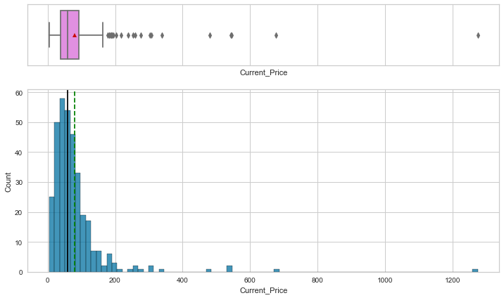

```python
histogram_boxplot(data, "Current_Price")
```

**Observations**

- Mean is greater than the median and data is skewed towards the right.
- There are many outliers towards the right.
- Mean is around 80 and median around 59.

### Observations on Price_Change

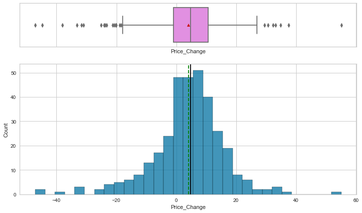

```python
histogram_boxplot(data, "Price_Change")
```

**Observations**

- It is an almost normal distribution with mean and median having values equal to 4.
- Values range from -40 to 60
- There are outlier towards both right and left

### Observations on Volatility

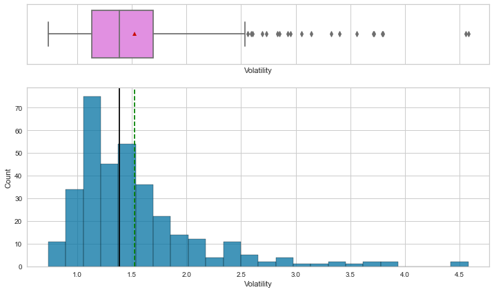

```python
histogram_boxplot(data, "Volatility")
```

**Observations**

- Mean is greater than the median and data is slightly skewed towards the right.
- There are many outliers towards the right.
- Mean is around 1.5 and median around 1.3.

### Observations on ROE

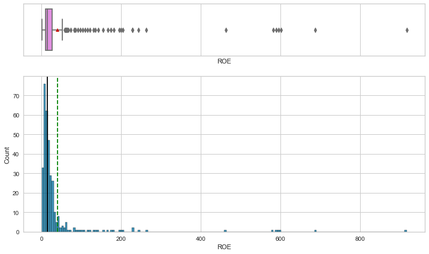

```python
histogram_boxplot(data, "ROE")
```

**Observations**

- Mean is greater than the median and data is slightly skewed towards the right.
- There are many outliers towards the right.
- Mean is around 39 and median around 15.

### Observations on Cash_Ratio

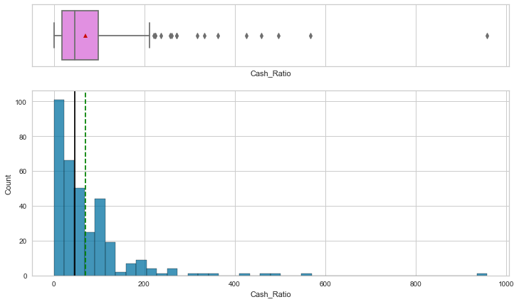

```python
histogram_boxplot(data, "Cash_Ratio")
```

**Observations**

- Mean is greater than the median and data is skewed towards the right.
- There are many outliers towards the right.
- Mean is around 70 and median around 47.

### Observations on Net_Cash_Flow

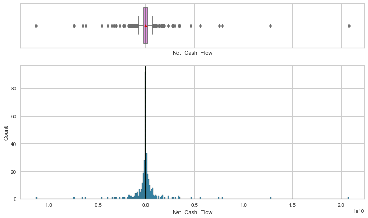

```python
histogram_boxplot(data, "Net_Cash_Flow")
```

**Observations**

- It is an almost normal distribution with mean and median having values of 5.553762e+07 and 2.098000e+06 respectively.
- There are outlier towards both right and left

### Observations on Net_Income

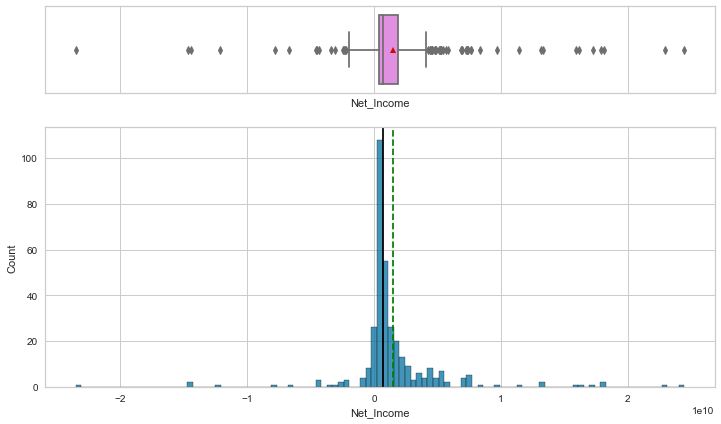

```python
histogram_boxplot(data, "Net_Income")
```

**Observations**

- Mean is greater than the median and data is skewed towards the right.
- There are outliers towards the right and left.
- Mean is around 1.494385e+09 and median around 7.073360e+08.

### Observations on Earnings_Per_Share

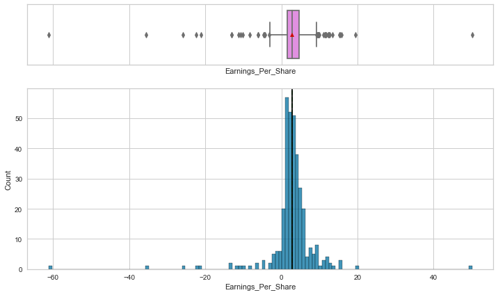

```python
histogram_boxplot(data, "Earnings_Per_Share")
```

**Observations**

- It is an almost normal distribution with mean and median having near values of 2.77 and 2.89 respectively.
- There are outlier towards both right and left.
- Values are ranging from -60 to 50.

### Observations on Estimated_Shares_Outstanding

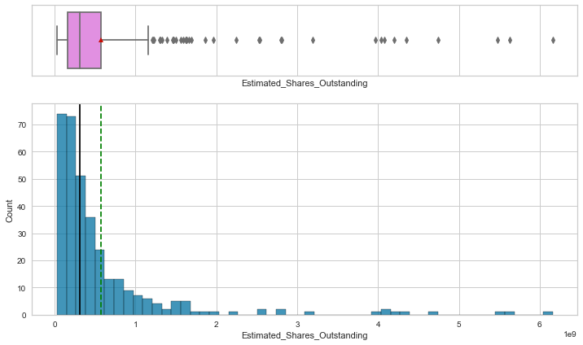

```python
histogram_boxplot(data, "Estimated_Shares_Outstanding")
```

**Observations**

- Mean is greater than the median and data is skewed towards the right.
- There are outliers towards the right.
- Mean is around 5.770283e+08 and median around 3.096751e+08.

### Observations on P/E_Ratio

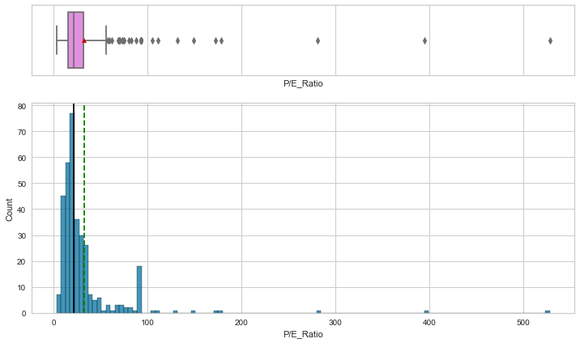

```python
histogram_boxplot(data, "P/E_Ratio")
```

**Observations**

- Mean is greater than the median and data is skewed towards the right.
- There are outliers towards the right.
- Mean is around 32 and median around 20.

### Observations on P/B_Ratio

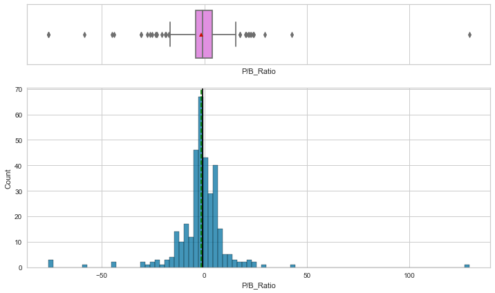

```python
histogram_boxplot(data, "P/B_Ratio")
```

**Observations**

- It is an almost normal distribution with mean and median having near values of -1.7 and -1.06 respectively.
- There are outlier towards both right and left.
- Values are ranging from -76 to 129.

### Let us now explore the categorical variables

```python
# function to create labeled barplots


def labeled_barplot(data, feature, perc=False, n=None):
    """
    Barplot with percentage at the top

    data: dataframe
    feature: dataframe column
    perc: whether to display percentages instead of count (default is False)
    n: displays the top n category levels (default is None, i.e., display all levels)
    """

    total = len(data[feature])  # length of the column
    count = data[feature].nunique()
    if n is None:
        plt.figure(figsize=(count + 30, 30))
    else:
        plt.figure(figsize=(n + 1, 5))

    plt.xticks(rotation=90, fontsize=15)
    ax = sns.countplot(
        data=data,
        x=feature,
        palette="Paired",
        order=data[feature].value_counts().index[:n].sort_values(),
    )

    for p in ax.patches:
        if perc == True:
            label = "{:.1f}%".format(
                100 * p.get_height() / total
            )  # percentage of each class of the category
        else:
            label = p.get_height()  # count of each level of the category

        x = p.get_x() + p.get_width() / 2  # width of the plot
        y = p.get_height()  # height of the plot

        ax.annotate(
            label,
            (x, y),
            ha="center",
            va="center",
            size=12,
            xytext=(0, 5),
            textcoords="offset points",
        )  # annotate the percentage

    plt.show()  # show the plot
```

### Observations on GICS_Sector

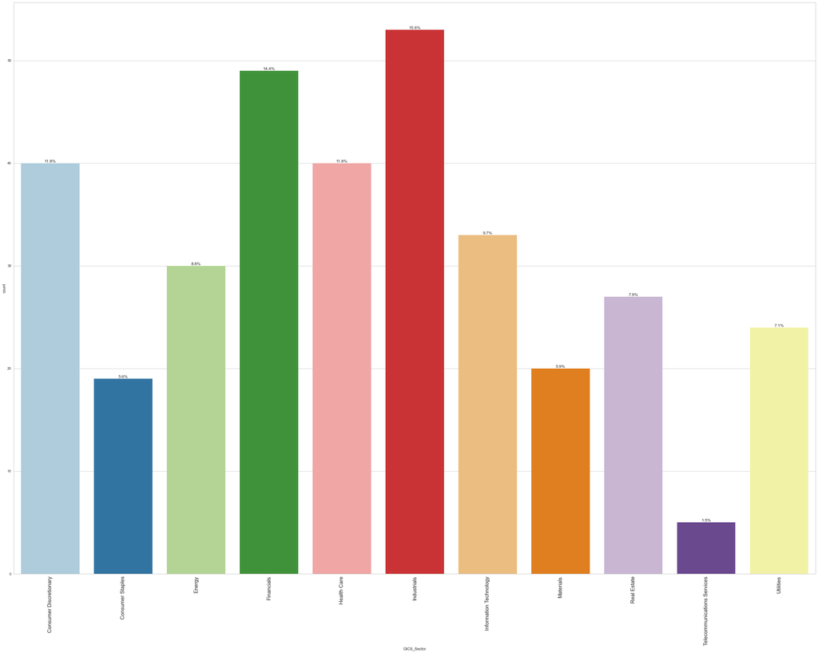

```python
labeled_barplot(data, "GICS_Sector", perc=True)
```

**Observations**

- Most of the comanies come under the sector Industirals with 15.6%
- Only 1.5% companies come under the sector Telecommunications Services.

### Observations on GICS_Sub_Industry

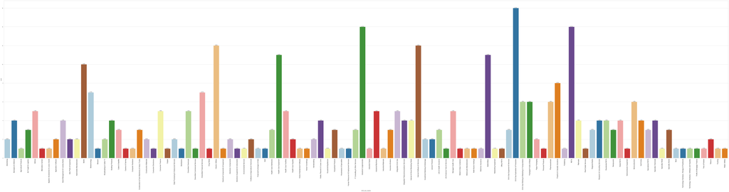

```python
labeled_barplot(data, "GICS_Sub_Industry", perc=True)
```

**Observations**

- The sub-sector 'Oil and Gas Exploration and Production' has the most count with 4.7%.
- The lowest percent is 0.3% and distributed among many sub-sectors.

## Bivariate Analysis

Plot bivariate charts between numeric variables to understand their interaction with each other.

### Correlation

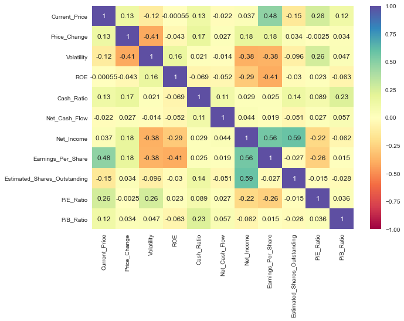

```python
plt.figure(figsize=(10, 7))
sns.heatmap(data.corr(), annot=True, vmin=-1, vmax=1, cmap="Spectral")
plt.show()
```

**Observations**

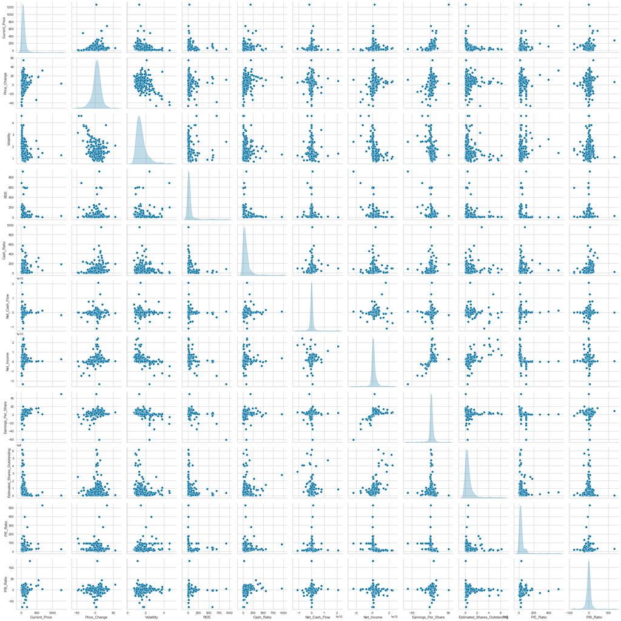

```python
sns.pairplot(data=data, diag_kind="kde")
plt.show()
```

**Observations**

- Volatility decreases as Price_Change increases.
- Earnings_Per_Share decreases as ROE increases.
- Earnings_Per_Share increases as Current_Price increases.

### Price_Change vs GICS Sector

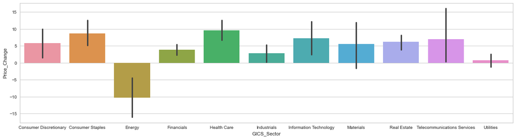

```python
plt.figure(figsize=(20, 5))
sns.barplot(data=data, x="GICS_Sector", y="Price_Change")
```

**Observations**

- HealthCare Sector has the highest average Price increase with around 10% increase.
- Utilities Sector had least average price increase with 1% increase.
- Energy Sector had price decrease with average of -10%.

### P/E Ratio vs GICS Sector

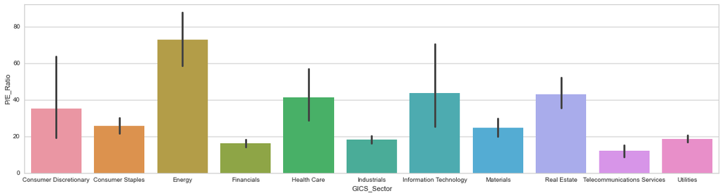

```python
plt.figure(figsize=(20, 5))
sns.barplot(data=data, x="GICS_Sector", y="P/E_Ratio")
```

**Observations**

- Engergy sector has the highest average of P/E ratio around 75.
- Telecommunications Services has the least average of P/E ratio around 15.

### Cash_Ratio vs GICS Sector

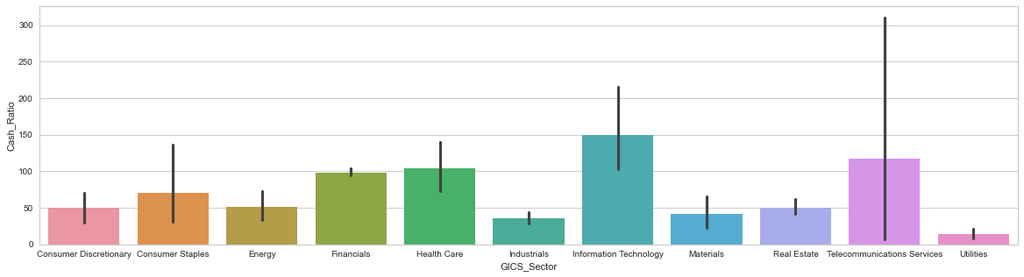

```python
plt.figure(figsize=(20, 5))
sns.barplot(data=data, x="GICS_Sector", y="Cash_Ratio")
```

**Observations**

- Information Technolgy sector has the highest average of Cash_Ratio around 150.
- Utilites sector has the least average of Cash_Ratio with average of around 15.

## Data Preprocessing (Contd..)

### Outlier Detection

From the boxplots of all the Numerical Variables we can see that all of them are having Outliers.

But since these are genuine data, we will not perform the Outlier Treatment.

## K-means Clustering

```python
# variables used for clustering
all_col = data.iloc[:, 4:].columns.tolist()
all_col
```

```
['Current_Price',
 'Price_Change',
 'Volatility',
 'ROE',
 'Cash_Ratio',
 'Net_Cash_Flow',
 'Net_Income',
 'Earnings_Per_Share',
 'Estimated_Shares_Outstanding',
 'P/E_Ratio',
 'P/B_Ratio']
```

```python
# Scaling the data set before clustering
scaler = StandardScaler()
subset = data[all_col].copy()
subset_scaled = scaler.fit_transform(subset)
```

```python
# Creating a dataframe from the scaled data above
subset_scaled_df = pd.DataFrame(subset_scaled, columns=subset.columns)
```

### Plot the Elbow curve

```
Number of Clusters: 1 	Average Distortion: 2.5425069919221697
Number of Clusters: 2 	Average Distortion: 2.382318498894466
Number of Clusters: 3 	Average Distortion: 2.2692367155390745
Number of Clusters: 4 	Average Distortion: 2.1770961257432995
Number of Clusters: 5 	Average Distortion: 2.1295231122469365
Number of Clusters: 6 	Average Distortion: 2.074742694217064
Number of Clusters: 7 	Average Distortion: 2.0312771801534404
Number of Clusters: 8 	Average Distortion: 1.959134391893239
```

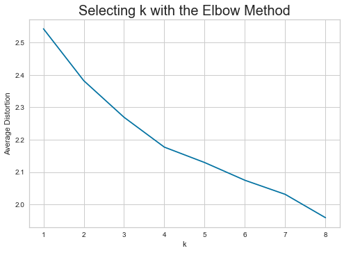

```python
clusters = range(1, 9)
meanDistortions = []

for k in clusters:
    model = KMeans(n_clusters=k)
    model.fit(subset_scaled_df)
    prediction = model.predict(subset_scaled_df)
    distortion = (
        sum(
            np.min(cdist(subset_scaled_df, model.cluster_centers_, "euclidean"), axis=1)
        )
        / subset_scaled_df.shape[0]
    )

    meanDistortions.append(distortion)

    print("Number of Clusters:", k, "\tAverage Distortion:", distortion)

plt.plot(clusters, meanDistortions, "bx-")
plt.xlabel("k")
plt.ylabel("Average Distortion")
plt.title("Selecting k with the Elbow Method", fontsize=20)
```

**The appropriate value of k from elbow curve seems to be 4 or 5**

### Lets us check silhoutte score¶

```python
sil_score = []
cluster_list = list(range(2, 10))
for n_clusters in cluster_list:
    clusterer = KMeans(n_clusters=n_clusters)
    preds = clusterer.fit_predict((subset_scaled_df))
    # centers = clusterer.cluster_centers_
    score = silhouette_score(subset_scaled_df, preds)
    sil_score.append(score)
    print("For n_clusters = {}, silhouette score is {})".format(n_clusters, score))
```

```
For n_clusters = 2, silhouette score is 0.4484662124740991)
For n_clusters = 3, silhouette score is 0.4644405674779404)
For n_clusters = 4, silhouette score is 0.4498948196526947)
For n_clusters = 5, silhouette score is 0.40690537338938215)
For n_clusters = 6, silhouette score is 0.38817178229053784)
For n_clusters = 7, silhouette score is 0.386652027638425)
For n_clusters = 8, silhouette score is 0.3886929719130642)
For n_clusters = 9, silhouette score is 0.4090171173372503)
```

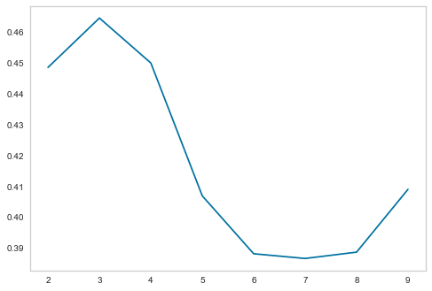

```python
plt.plot(cluster_list, sil_score)
plt.grid()
```

**From silhouette score, it seems that 3 and 4 are good values of k**

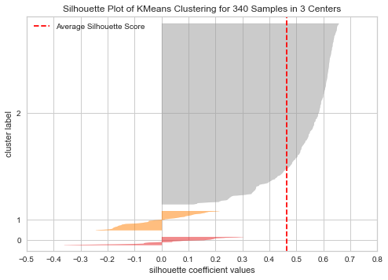

```python
# Finding optimal no. of clusters with silhouette coefficients
visualizer = SilhouetteVisualizer(KMeans(3, random_state=1))
visualizer.fit(subset_scaled_df)
visualizer.show()
```

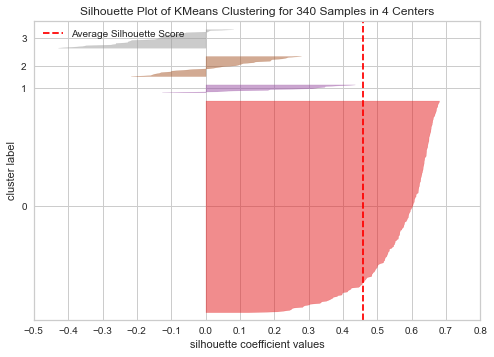

```python
# Finding optimal no. of clusters with silhouette coefficients
visualizer = SilhouetteVisualizer(KMeans(4, random_state=1))
visualizer.fit(subset_scaled_df)
visualizer.show()
```

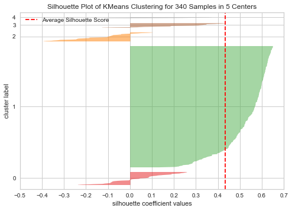

```python
# Finding optimal no. of clusters with silhouette coefficients
visualizer = SilhouetteVisualizer(KMeans(5, random_state=1))
visualizer.fit(subset_scaled_df)
visualizer.show()
```

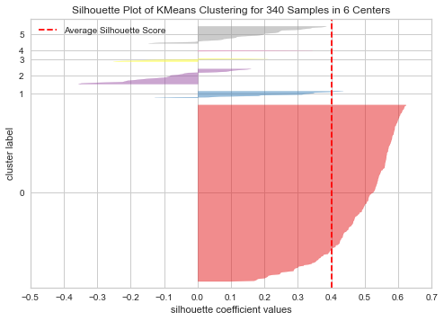

```python
# Finding optimal no. of clusters with silhouette coefficients
visualizer = SilhouetteVisualizer(KMeans(6, random_state=1))
visualizer.fit(subset_scaled_df)
visualizer.show()
```

### Let us take 4 as appropriate no. of clusters as silhoutte score is high enough and there is knick at 4 in elbow curve.

```python
kmeans = KMeans(n_clusters=4, random_state=0)
kmeans.fit(subset_scaled_df)
```

```
KMeans(n_clusters=4, random_state=0)
```

```python
data["K_means_segments"] = kmeans.labels_
```

```python
cluster_profile = data.groupby("K_means_segments").mean()
```

```python
cluster_profile["count_in_each_segment"] = (
    data.groupby("K_means_segments")["Security"].count().values
)
```

```python
# lets display cluster profile
cluster_profile.style.highlight_max(color="lightgreen", axis=0)
```

| K_means_segments | Current_Price | Price_Change | Volatility | ROE | Cash_Ratio | Net_Cash_Flow | Net_Income | Earnings_Per_Share | Estimated_Shares_Outstanding | P/E_Ratio | P/B_Ratio | count_in_each_segment |
| --- | --- | --- | --- | --- | --- | --- | --- | --- | --- | --- | --- | --- |
| 0 | 234.170932 | 13.400685 | 1.729989 | 25.600000 | 277.640000 | 1554926560.000000 | 1572611680.000000 | 6.045200 | 578316318.948800 | 74.960824 | 14.402452 | 25 |
| 1 | 38.099260 | -15.370329 | 2.910500 | 107.074074 | 50.037037 | -159428481.481481 | -3887457740.740741 | -9.473704 | 480398572.845926 | 90.619220 | 1.342067 | 27 |
| 2 | 50.517273 | 5.747586 | 1.130399 | 31.090909 | 75.909091 | -1072272727.272727 | 14833090909.090910 | 4.154545 | 4298826628.727273 | 14.803577 | -4.552119 | 11 |
| 3 | 72.399112 | 5.066225 | 1.388319 | 34.620939 | 53.000000 | -14046223.826715 | 1482212389.891697 | 3.621029 | 438533835.667184 | 23.843656 | -3.358948 | 277 |

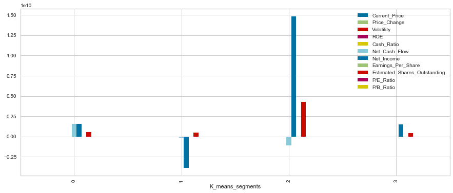

```python
data.groupby("K_means_segments").mean().plot.bar(figsize=(15, 6))
```

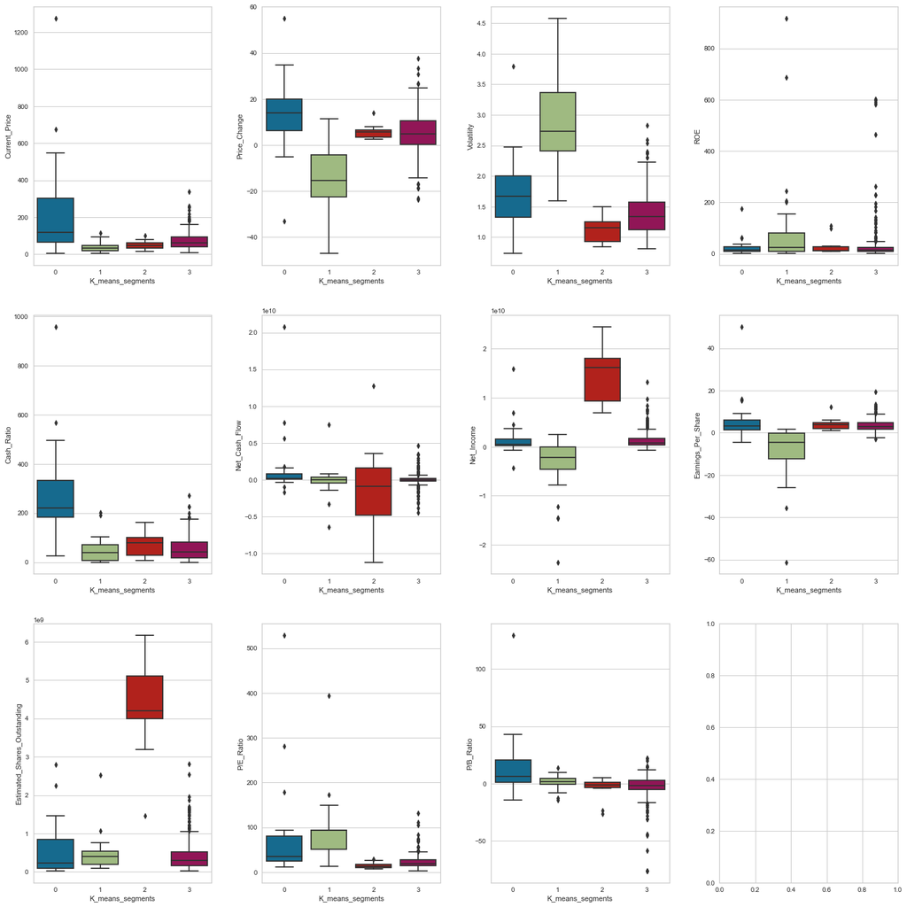

```python
fig, axes = plt.subplots(3, 4, figsize=(20, 20))
counter = 0

for ii in range(3):
    for jj in range(4):
        if counter < 11:
            sns.boxplot(
                ax=axes[ii][jj],
                data=data,
                y=data[all_col[counter]],
                x=data["K_means_segments"],
            )
        counter = counter + 1

fig.tight_layout(pad=3.0)
```

### Insights

**Cluster 0 :**

- Current Price, Price Change, Cash_Ratio, Net_Cash_Flow, Earnings_Per_Share and P/B Ratio of the comapnies is the highest.
- ROE is the lowest.

**Cluster 1 :**

- Volatility, ROE and P/E Ratio of the comapnies is the highest.
- Current Price, Price Change, Cash_Ratio, Net_Income, Earnings_Per_Share are the lowest.

**Cluster 2 :**

- Net_Income and Estimated_Shares_outstanding is the highest.
- Volatility,Net_Cash_Flow, P/E Ratio and P/B Ratio are the lowest.

## Hierarchical Clustering

```python
# list of distance metrics
distance_metrics = ["euclidean", "chebyshev", "mahalanobis", "cityblock"]

# list of linkage methods
linkage_methods = ["single", "complete", "average", "weighted"]

high_cophenet_corr = 0
high_dm_lm = [0, 0]

for dm in distance_metrics:
    for lm in linkage_methods:
        Z = linkage(subset_scaled_df, metric=dm, method=lm)
        c, coph_dists = cophenet(Z, pdist(subset_scaled_df))
        print(
            "Cophenetic correlation for {} distance and {} linkage is {}.".format(
                dm.capitalize(), lm, c
            )
        )
        if high_cophenet_corr < c:
            high_cophenet_corr = c
            high_dm_lm[0] = dm
            high_dm_lm[1] = lm
```

```
Cophenetic correlation for Euclidean distance and single linkage is 0.9232271494002922.
Cophenetic correlation for Euclidean distance and complete linkage is 0.7873280186580672.
Cophenetic correlation for Euclidean distance and average linkage is 0.9422540609560814.
Cophenetic correlation for Euclidean distance and weighted linkage is 0.8693784298129404.
Cophenetic correlation for Chebyshev distance and single linkage is 0.9062538164750717.
Cophenetic correlation for Chebyshev distance and complete linkage is 0.598891419111242.
Cophenetic correlation for Chebyshev distance and average linkage is 0.9338265528030499.
Cophenetic correlation for Chebyshev distance and weighted linkage is 0.9127355892367.
Cophenetic correlation for Mahalanobis distance and single linkage is 0.9259195530524589.
Cophenetic correlation for Mahalanobis distance and complete linkage is 0.7925307202850003.
Cophenetic correlation for Mahalanobis distance and average linkage is 0.9247324030159737.
Cophenetic correlation for Mahalanobis distance and weighted linkage is 0.8708317490180426.
Cophenetic correlation for Cityblock distance and single linkage is 0.9334186366528574.
Cophenetic correlation for Cityblock distance and complete linkage is 0.7375328863205818.
Cophenetic correlation for Cityblock distance and average linkage is 0.9302145048594667.
Cophenetic correlation for Cityblock distance and weighted linkage is 0.731045513520281.
```

```python
# printing the combination of distance metric and linkage method with the highest cophenetic correlation
print(
    "Highest cophenetic correlation is {}, which is obtained with {} distance and {} linkage.".format(
        high_cophenet_corr, high_dm_lm[0].capitalize(), high_dm_lm[1]
    )
)
```

```
Highest cophenetic correlation is 0.9422540609560814, which is obtained with Euclidean distance and average linkage.
```

### Let's explore different linkage methods with Euclidean distance only.

```python
# list of linkage methods
linkage_methods = ["single", "complete", "average", "centroid", "ward", "weighted"]

high_cophenet_corr = 0
high_dm_lm = [0, 0]

for lm in linkage_methods:
    Z = linkage(subset_scaled_df, metric="euclidean", method=lm)
    c, coph_dists = cophenet(Z, pdist(subset_scaled_df))
    print("Cophenetic correlation for {} linkage is {}.".format(lm, c))
    if high_cophenet_corr < c:
        high_cophenet_corr = c
        high_dm_lm[0] = "euclidean"
        high_dm_lm[1] = lm
```

```
Cophenetic correlation for single linkage is 0.9232271494002922.
Cophenetic correlation for complete linkage is 0.7873280186580672.
Cophenetic correlation for average linkage is 0.9422540609560814.
Cophenetic correlation for centroid linkage is 0.9314012446828154.
Cophenetic correlation for ward linkage is 0.7101180299865353.
Cophenetic correlation for weighted linkage is 0.8693784298129404.
```

```python
# printing the combination of distance metric and linkage method with the highest cophenetic correlation
print(
    "Highest cophenetic correlation is {}, which is obtained with {} linkage.".format(
        high_cophenet_corr, high_dm_lm[1]
    )
)
```

```
Highest cophenetic correlation is 0.9422540609560814, which is obtained with average linkage.
```

**We see that the cophenetic correlation is maximum with Euclidean distance and average linkage.**

### Let's see the dendrograms for the different linkage methods.

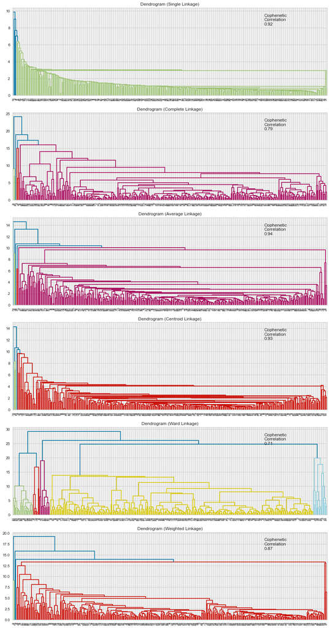

```python
# list of linkage methods
linkage_methods = ["single", "complete", "average", "centroid", "ward", "weighted"]

# lists to save results of cophenetic correlation calculation
compare_cols = ["Linkage", "Cophenetic Coefficient"]
compare = []

# to create a subplot image
fig, axs = plt.subplots(len(linkage_methods), 1, figsize=(15, 30))

# We will enumerate through the list of linkage methods above
# For each linkage method, we will plot the dendrogram and calculate the cophenetic correlation
for i, method in enumerate(linkage_methods):
    Z = linkage(subset_scaled_df, metric="euclidean", method=method)

    dendrogram(Z, ax=axs[i])
    axs[i].set_title(f"Dendrogram ({method.capitalize()} Linkage)")

    coph_corr, coph_dist = cophenet(Z, pdist(subset_scaled_df))
    axs[i].annotate(
        f"Cophenetic\nCorrelation\n{coph_corr:0.2f}",
        (0.80, 0.80),
        xycoords="axes fraction",
    )

    compare.append([method, coph_corr])
```

**Observations**

- The cophenetic correlation is highest for average and centroid linkage methods.
- We will move ahead with average linkage.
- 6 appears to be the appropriate number of clusters from the dendrogram for average linkage.

```python
HCmodel = AgglomerativeClustering(n_clusters=6, affinity="euclidean", linkage="average")
HCmodel.fit(subset_scaled_df)
```

```
AgglomerativeClustering(linkage='average', n_clusters=6)
```

```python
subset_scaled_df["HC_Clusters"] = HCmodel.labels_
data["HC_Clusters"] = HCmodel.labels_
```

## Cluster Profiling¶

```python
cluster_profile = data.groupby("HC_Clusters").mean()
```

```python
cluster_profile["count_in_each_segments"] = (
    data.groupby("HC_Clusters")["Security"].count().values
)
```

```python
# let's see the names of the countries in each cluster

for cl in data["HC_Clusters"].unique():
    print("In cluster {}, the following companies are present:".format(cl))
    print(data[data["HC_Clusters"] == cl]["Security"].unique())
    print()
```

```
In cluster 0, the following companies are present:
['American Airlines Group', 'AbbVie', 'Abbott Laboratories', 'Adobe Systems Inc', 'Analog Devices, Inc.', ..., 'Yahoo Inc.', 'Yum! Brands Inc', 'Zimmer Biomet Holdings', 'Zions Bancorp', 'Zoetis']
Length: 333
Categories (333, object): ['American Airlines Group', 'AbbVie', 'Abbott Laboratories', 'Adobe Systems Inc', ..., 'Yum! Brands Inc', 'Zimmer Biomet Holdings', 'Zions Bancorp', 'Zoetis']

In cluster 5, the following companies are present:
['Alliance Data Systems']
Categories (1, object): ['Alliance Data Systems']

In cluster 2, the following companies are present:
['Apache Corporation', 'Chesapeake Energy']
Categories (2, object): ['Apache Corporation', 'Chesapeake Energy']

In cluster 1, the following companies are present:
['Bank of America Corp', 'Intel Corp.']
Categories (2, object): ['Bank of America Corp', 'Intel Corp.']

In cluster 3, the following companies are present:
['Facebook']
Categories (1, object): ['Facebook']

In cluster 4, the following companies are present:
['Priceline.com Inc']
Categories (1, object): ['Priceline.com Inc']
```

```python
# lets display cluster profile
cluster_profile.style.highlight_max(color="lightgreen", axis=0)
```

| HC_Clusters | Current_Price | Price_Change | Volatility | ROE | Cash_Ratio | Net_Cash_Flow | Net_Income | Earnings_Per_Share | Estimated_Shares_Outstanding | P/E_Ratio | P/B_Ratio | K_means_segments | count_in_each_segments |
| --- | --- | --- | --- | --- | --- | --- | --- | --- | --- | --- | --- | --- | --- |
| 0 | 77.287589 | 4.099730 | 1.518066 | 35.336336 | 66.900901 | -33197321.321321 | 1538074666.666667 | 2.885270 | 560505037.293543 | 32.441706 | -2.174921 | 2.630631 | 333 |
| 1 | 25.640000 | 11.237908 | 1.322355 | 12.500000 | 130.500000 | 16755500000.000000 | 13654000000.000000 | 3.295000 | 2791829362.100000 | 13.649696 | 1.508484 | 1.000000 | 2 |
| 2 | 24.485001 | -13.351992 | 3.482611 | 802.000000 | 51.000000 | -1292500000.000000 | -19106500000.000000 | -41.815000 | 519573983.250000 | 60.748608 | 1.565141 | 1.000000 | 2 |
| 3 | 104.660004 | 16.224320 | 1.320606 | 8.000000 | 958.000000 | 592000000.000000 | 3669000000.000000 | 1.310000 | 2800763359.000000 | 79.893133 | 5.884467 | 0.000000 | 1 |
| 4 | 1274.949951 | 3.190527 | 1.268340 | 29.000000 | 184.000000 | -1671386000.000000 | 2551360000.000000 | 50.090000 | 50935516.070000 | 25.453183 | -1.052429 | 0.000000 | 1 |
| 5 | 276.570007 | 6.189286 | 1.116976 | 30.000000 | 25.000000 | 90885000.000000 | 596541000.000000 | 8.910000 | 66951851.850000 | 31.040405 | 129.064585 | 0.000000 | 1 |

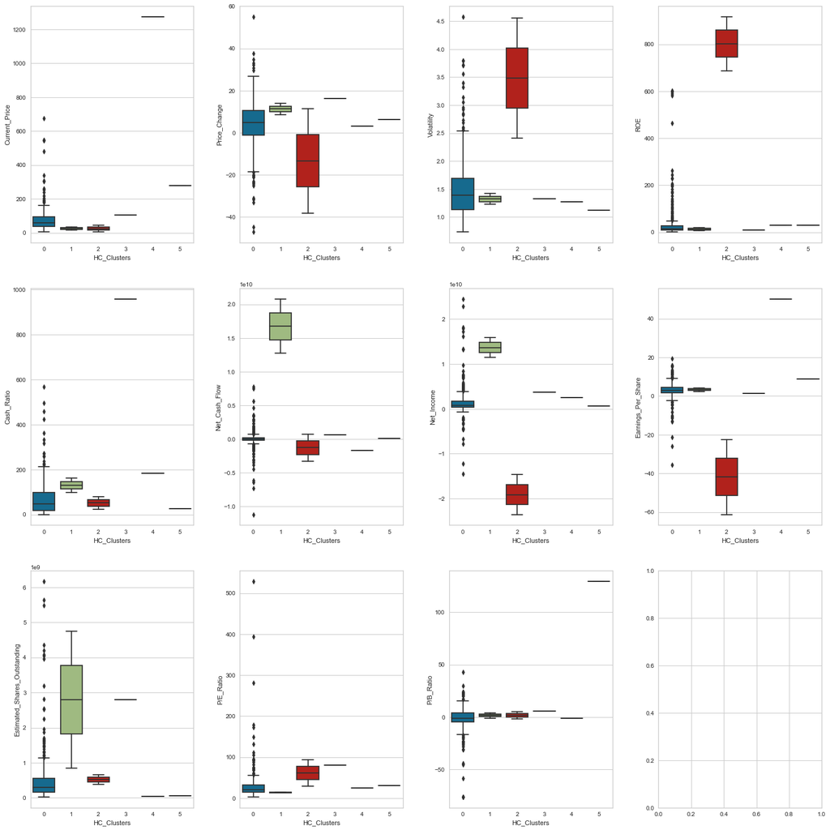

```python
fig, axes = plt.subplots(3, 4, figsize=(20, 20))
counter = 0

for ii in range(3):
    for jj in range(4):
        if counter < 11:
            sns.boxplot(
                ax=axes[ii][jj],
                data=data,
                y=data[all_col[counter]],
                x=data["HC_Clusters"],
            )
        counter = counter + 1

fig.tight_layout(pad=3.0)
```

```python
# lets display cluster profile
cluster_profile.style.highlight_max(color="lightgreen", axis=0).highlight_min(
    color="yellow", axis=0
)
```

| HC_Clusters | Current_Price | Price_Change | Volatility | ROE | Cash_Ratio | Net_Cash_Flow | Net_Income | Earnings_Per_Share | Estimated_Shares_Outstanding | P/E_Ratio | P/B_Ratio | K_means_segments | count_in_each_segments |
| --- | --- | --- | --- | --- | --- | --- | --- | --- | --- | --- | --- | --- | --- |
| 0 | 77.287589 | 4.099730 | 1.518066 | 35.336336 | 66.900901 | -33197321.321321 | 1538074666.666667 | 2.885270 | 560505037.293543 | 32.441706 | -2.174921 | 2.630631 | 333 |
| 1 | 25.640000 | 11.237908 | 1.322355 | 12.500000 | 130.500000 | 16755500000.000000 | 13654000000.000000 | 3.295000 | 2791829362.100000 | 13.649696 | 1.508484 | 1.000000 | 2 |
| 2 | 24.485001 | -13.351992 | 3.482611 | 802.000000 | 51.000000 | -1292500000.000000 | -19106500000.000000 | -41.815000 | 519573983.250000 | 60.748608 | 1.565141 | 1.000000 | 2 |
| 3 | 104.660004 | 16.224320 | 1.320606 | 8.000000 | 958.000000 | 592000000.000000 | 3669000000.000000 | 1.310000 | 2800763359.000000 | 79.893133 | 5.884467 | 0.000000 | 1 |
| 4 | 1274.949951 | 3.190527 | 1.268340 | 29.000000 | 184.000000 | -1671386000.000000 | 2551360000.000000 | 50.090000 | 50935516.070000 | 25.453183 | -1.052429 | 0.000000 | 1 |
| 5 | 276.570007 | 6.189286 | 1.116976 | 30.000000 | 25.000000 | 90885000.000000 | 596541000.000000 | 8.910000 | 66951851.850000 | 31.040405 | 129.064585 | 0.000000 | 1 |

### Insights

**Cluster 0 :**

- It has highest number of comapnies 333.
- No Indicators are high
- P/B ratio is lowest.

**Cluster 1 :**

- Net_Cash_Flow,Net_income is the highest.
- P/E Ratio is the least.

**Cluster 2 :**

- Volatility and ROE is the highest.
- Current_Price, Price_Change,Net_income,Earnings_Per_Share are the lowest.

**Cluster 3:**

- Price_Change,Estimated_Shares_outstanding,P/E Ratio and Cash_Ratio are the highest.
- ROE is the lowest.

**Cluster 4:**

- Current_Price,Earnings_Per_Share are the highest.
- Net_Cash_Flow,Estimated_Shares_outstanding is the lowest.

**Cluster 5:**

- P/B Ratio is the highest.
- Volatility and Cash Ratio is the lowest.

## K-means vs Hierarchical Clustering

- K-Means Clustering had companies more Spread out between differnt clusters as :25,27,11,277
- In HC it is 333,2,2,1,1,1 which indicaes no variability
- In K-Means Cluster 0 has Current Price, Price Change, Cash_Ratio, Net_Cash_Flow, Earnings_Per_Share and P/B Ratio of the comapnies is the highest and ROE is the lowest. This makes it easier to pick as the Best Cluster.
- In HC some indicaters are high on some clusters . There is no definite indication of which cluster is the best.

## Actionable Insights and Recommendations

- Use K-Means Clustering Technique.

**Cluster 0 :**

- Current Price, Price Change, Cash_Ratio, Net_Cash_Flow, Earnings_Per_Share and P/B Ratio of the comapnies is the highest.
- ROE is the lowest.

**Cluster 1 :**

- Volatility, ROE and P/E Ratio of the comapnies is the highest.
- Current Price, Price Change, Cash_Ratio, Net_Income, Earnings_Per_Share are the lowest.

**Cluster 2 :**

- Net_Income and Estimated_Shares_outstanding is the highest.
- Volatility,Net_Cash_Flow, P/E Ratio and P/B Ratio are the lowest.

**Cluster 3:**